# Spotify Dataset Analysis

Author

Collin McNeil

Published

January 28, 2026

## Introduction

This report analyzes a dataset of popular songs from Spotify

The goal of this analysis is to explore patterns in the data and understand how musical features relate to one another and song popularity.

## Data Overview

The Spotify dataset contains the following variables:

- **streams_mill**: Number of streams in millions
- **released_month**: Month the song was released (1-12)
- **mode**: Musical mode (Major or Minor)
- **key**: Musical key (12 different keys)
- **bpm**: Tempo in beats per minute
- **danceability**: Danceability score (0-100)
- **energy**: Energy level (0-100)
- **liveness**: Likelihood of live performance recording

## Visual Analysis

### Musical Characteristics: Live vs. Studio Recordings

The visualization below compares musical characteristics between live performances (liveness ≥ 50) and studio recordings (liveness < 50). Live recordings may exhibit different energy patterns, streaming performance, and musical features compared to their studio-produced counterparts.

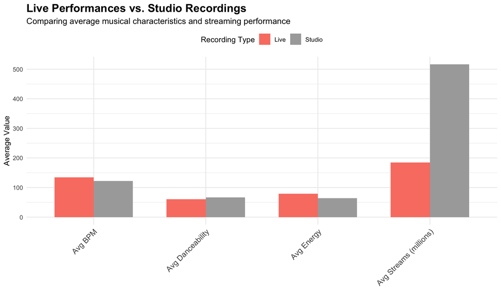

## Summary Table Analysis

### Major vs. Minor Mode Comparison

The table below compares songs in major and minor keys across several dimensions. Musical mode can influence the emotional tone of a song, and this analysis examines whether mode correlates with other musical features or streaming success.

Summary Statistics by Musical Mode

| mode | Number of Songs | Avg Streams (millions) | Median Streams (millions) | Avg BPM | Avg Danceability | Avg Energy |
| --- | --- | --- | --- | --- | --- | --- |
| Major | 547 | 536.37 | 303.22 | 123.0 | 65.2 | 63.5 |
| Minor | 401 | 484.11 | 273.01 | 121.8 | 69.3 | 65.3 |

### Top Streaming Songs

The interactive table below displays songs sorted by streaming numbers, allowing exploration of the most popular tracks and their characteristics. Use the search and filter features to identify patterns among top performers.

| Streams (millions) | Mode | Key | BPM | Danceability | Energy | Release Month |
| --- | --- | --- | --- | --- | --- | --- |
| 3703.895074 | Major | C# | 171 | 50 | 80 | 11 |
| 3562.54389 | Minor | C# | 96 | 83 | 65 | 1 |
| 2887.241814 | Major | C# | 110 | 50 | 41 | 11 |
| 2864.791672 | Minor | F# | 98 | 82 | 59 | 5 |
| 2808.09655 | Major | D | 90 | 76 | 50 | 10 |
| 2713.92235 | Major | C# | 104 | 77 | 63 | 4 |
| 2665.343922 | Major | C# | 170 | 59 | 76 | 7 |
| 2594.040133 | Minor | A# | 125 | 77 | 78 | 1 |
| 2591.224264 | Major | G# | 95 | 75 | 52 | 5 |
| 2565.529693 | Major | G | 186 | 68 | 59 | 9 |

[output cut: 938 more lines]

## Conclusion

This analysis reveals several interesting patterns in the Spotidy dataset. Studio recordings dominate both the dataset and streaming performance, with live recordings representing a small number of recordings. The comparison between major and minor modes shows that while mode influences certain musical characteristics like danceability, it does not appear to significantly impact streaming success.

The most popular songs span a wide range of musical keys, tempos, and characteristics, suggesting that commercial success is multifaceted and not solely determined by individual musical attributes. Both highly danceable tracks and more subdued songs can achieve significant streaming numbers, reflecting diverse listener preferences on the platform.